# Predicting US Consumer Spending

#### Visual Diagram of Neural Network

```r
plot(fit.nn2)
```

[output not shown]

Step 2: Forecast teh next 8 periods for the basic model (NN2) using parameters derived from model fit summary

#### NN2 Model Forecast Results & Visual Plot

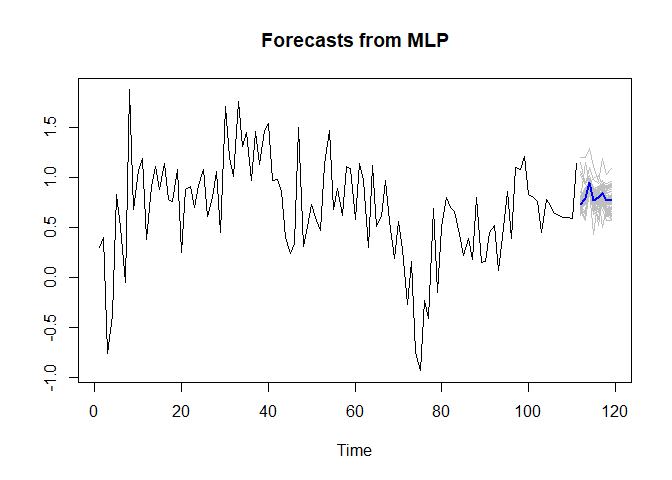

```r
fore.nn2 = forecast(fit.nn2, h=8)
plot(fore.nn2)
```

```r
fore.nn2
```

```
##     Point Forecast
## 112      0.7293060
## 113      0.7871380
## 114      0.9458783
## 115      0.7727762
## 116      0.8013214
## 117      0.8415191
## 118      0.7680472
## 119      0.7725997
```

Step 3: Compare forecasted datapoints to actual data points to visualize difference

##### NN2 Model Forecast Vs. Actual US Consumption Results

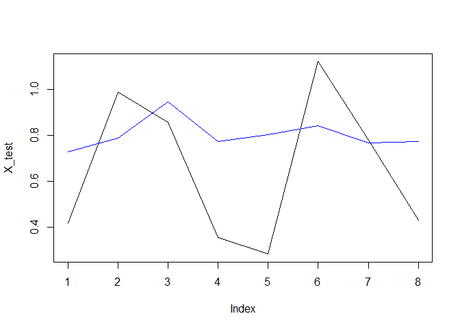

```r
plot(X_test, type="l")
lines(seq(1,8), fore.nn2$mean, col="blue")
```

Step 4: Calculate ASE for future comparison purposes:

#### ASE for (Basic Univariate) Neural Network Model 2:

```r
nn2.ASE = mean((X_test - fore.nn2$mean)^2)
nn2.ASE
```

```
## [1] 0.09789048
```

#### **Model 3: Multivariate Neural Network Model 3**

We will construct two multivariate models. The first model assumes that each regressor time series for the period forecasted is known. The second model does not assume that all regressor data points are known. We will first model each regressor using the neural network modeling technique and forecast estimates for the next 8 quarters (same outlook period as response variable). We will then use those forecasts to create a new regressor data frame that will be used in for the neural network model that will be used to forecast 2 year (8 qtr) estimates for the quarterly change in US Consumption.

Note: Regressor variables include: Disposable Income, Personal Income per Capita, Consumer Debt, and Consumer Confidence. Please refer to the EDA section for individual plots of each regressor time series.

Step 1: Run multivariate MLP model. Allow program to select parameter estimates. Run 100 reps.

##### Multivariate Neural Network (NN3) Model fit Summary

```r
fit.nn3 = mlp(X_train, reps=100, xreg= X_regressor)
fit.nn3
```

```
## MLP fit with 5 hidden nodes and 100 repetitions.
## Univariate lags: (1,2,3)
## 4 regressors included.
## - Regressor 1 lags: (1,4)
## - Regressor 2 lags: (1)
## - Regressor 3 lags: (1)
## - Regressor 4 lags: (3)
## Forecast combined using the median operator.
## MSE: 0.019.
```

#### Visual Diagram of Neural Network

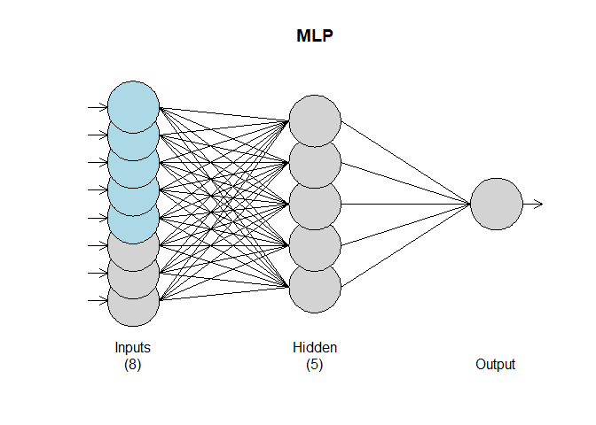

```r
plot(fit.nn3)
```

Step 2: Forecast the next 8 periods for the multivariate model (NN3) using parameters derived from model fit summary

#### NN3 Model Forecast Results & Visual Plot

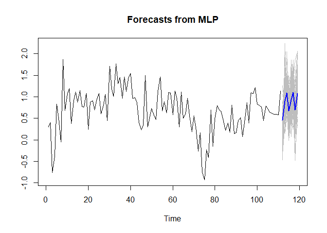

```r
fore.nn3 = forecast(fit.nn3, h=8, xreg= X_regressor)
plot(fore.nn3)
```

```r
fore.nn3
```

```
##     Point Forecast
## 112      0.4540116
## 113      0.8971961
## 114      1.0923710
## 115      0.6709059
## 116      0.9374149
## 117      1.0978592
## 118      0.6920305
## 119      1.0805337
```

Step 3: Compare forecasted datapoints to actual data points to visualize difference

##### NN3 Model Forecast Vs. Actual US Consumption Results

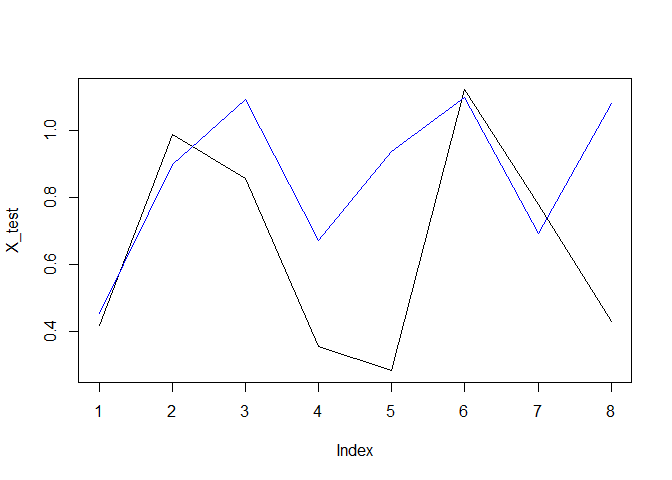

```r
plot(X_test, type="l")
lines(seq(1,8), fore.nn3$mean, col="blue")
```

Step 4: Calculate ASE for future comparison purposes:

#### ASE for Multivariate Neural Network Model 3:

```r
nn3.ASE = mean((X_test - fore.nn3$mean)^2)
nn3.ASE
```

```
## [1] 0.1281154
```

#### **Model 4: Multivariate Neural Network Model 4**

Multivariate Neural Network Model 4 does not assume that all regressor data points are known. For this model, we will first model each regressor using the neural network modeling technique and forecast estimates for the next 8 quarters (same outlook period as response variable). We will then use those forecasts to create a new regressor data frame that will be used in for the neural network model that will be used to forecast 2 year (8 qtr) estimates for the quarterly change in US Consumption.

Note: Regressor variables include: Disposable Income, Personal Income per Capita, Consumer Debt, and Consumer Confidence. Please refer to the EDA section for individual plots of each regressor time series.

**Part 1:** Use multilayer Perceptron (MLP) to forecast the next 8 periods for each regressor variable time series. Note- Regressor data cannot be modeled all at one time. Resulting forecasts must produce independant results. This implies that each regressor is modeled separately.

#### **Regressor Data Forecast: Disposable Income (fx1)**

Step 1: Run basic model for response variable only. Allow program to select parameter estimates. Run 100 reps.

##### Basic Neural Network (fx1) Model fit Summary

```r
fit.fx1 = mlp(X1, reps = 100)
fit.fx1
```

```
## MLP fit with 5 hidden nodes and 100 repetitions.
## Univariate lags: (1,2)
## Forecast combined using the median operator.
## MSE: 0.4152.
```

#### Visual Diagram of Neural Network

```r
plot(fit.fx1)
```

[output not shown]

Step 2: Forecast the next 8 periods for the basic model using parameters derived from model fit summary

#### Results of Regressor Forecast for Disposable Income (fx1)

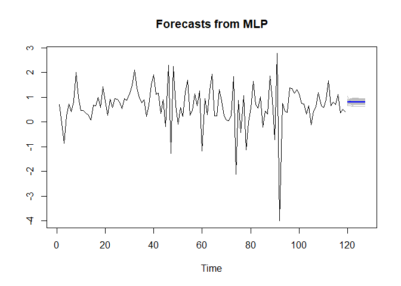

```r
fore.fx1 = forecast(fit.fx1, h=8)
plot(fore.fx1)
```

```r
fore.fx1
```

```
##     Point Forecast
## 120      0.8086710
## 121      0.8173217
## 122      0.8067412
## 123      0.8048682
## 124      0.8068356
## 125      0.8069205
## 126      0.8070576
## 127      0.8069910
```

```r
#Combine forecasted values with existing data
fx1 = EI$DisponsableIncome[1:111]
fx1[112:119] = fore.fx1$mean[1:8]
```

#### **Regressor Data Forecast: Personal Income per Capita (fx2)**

Step 1: Run basic model for response variable only. Allow program to select parameter estimates. Run 100 reps.

##### Basic Neural Network (fx2) Model fit Summary

```r
fit.fx2 = mlp(X2, reps = 100)
fit.fx2
```

```
## MLP fit with 5 hidden nodes and 100 repetitions.
## Univariate lags: (1,2)
## Forecast combined using the median operator.
## MSE: 0.5368.
```

#### Visual Diagram of Neural Network

```r
plot(fit.fx2)
```

[output not shown]

Step 2: Forecast the next 8 periods for the basic model using parameters derived from model fit summary

#### Results of Regressor Forecast for Personal Income per Capita (fx2)

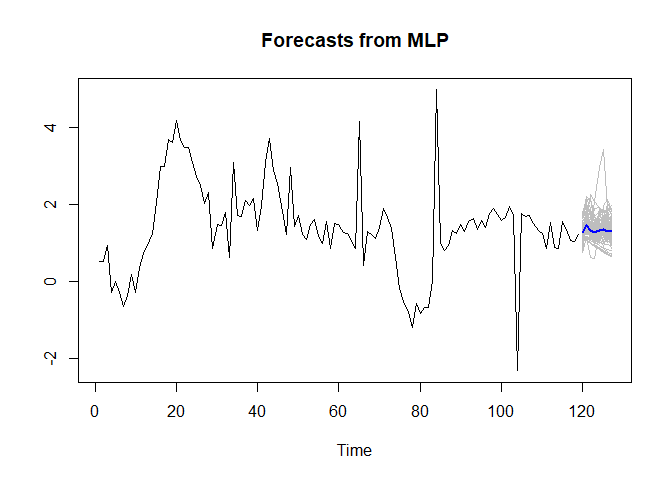

```r
fore.fx2 = forecast(fit.fx2, h=8)
plot(fore.fx2)
```

```r
fore.fx2
```

```
##     Point Forecast
## 120       1.264410
## 121       1.454720
## 122       1.323678
## 123       1.271923
## 124       1.330804
## 125       1.351970
## 126       1.296106
## 127       1.305469
```

```r
#Combine forecasted values with existing data
fx2 = EI$PersonalIncomePerCapita[1:111]
fx2[112:119] = fore.fx2$mean[1:8]
```

#### **Regressor Data Forecast: Consumer Debt (fx3)**

Step 1: Run basic model for response variable only. Allow program to select parameter estimates. Run 100 reps.

##### Basic Neural Network (fx3) Model fit Summary

```r
fit.fx3 = mlp(X3, reps = 100)
fit.fx3
```

```
## MLP fit with 5 hidden nodes and 100 repetitions.
## Univariate lags: (2)
## Forecast combined using the median operator.
## MSE: 0.5916.
```

#### Visual Diagram of Neural Network

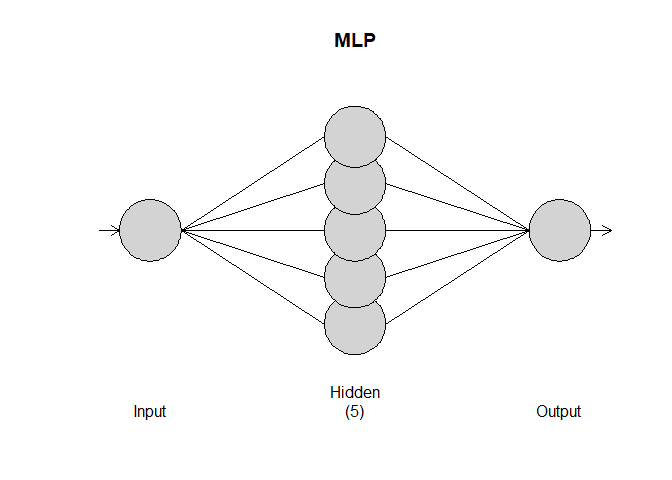

```r
plot(fit.fx3)
```

Step 2: Forecast the next 8 periods for the basic model using parameters derived from model fit summary

#### Results of Regressor Forecast for Consumer Debt (fx3)

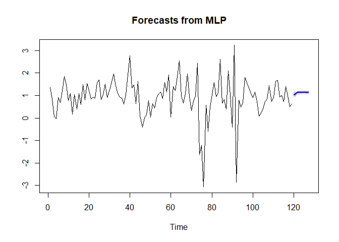

```r
fore.fx3 = forecast(fit.fx3, h=8)
plot(fore.fx3)
```

```r
fore.fx3
```

```
##     Point Forecast
## 120       1.024128
## 121       1.082456
## 122       1.148723
## 123       1.144814
## 124       1.133736
## 125       1.135290
## 126       1.137201
## 127       1.136888
```

```r
#Combine forecasted values with existing data
fx3 = EI$ConsumerDebt[1:111]
fx3[112:119] = fore.fx3$mean[1:8]
```

#### **Regressor Data Forecast: Consumer Confidence (fx4)**

Step 1: Run basic model for response variable only. Allow program to select parameter estimates. Run 100 reps.

##### Basic Neural Network (fx4) Model fit Summary

```r
fit.fx4 = mlp(X4, reps = 100)
fit.fx4
```

```
## MLP fit with 5 hidden nodes and 100 repetitions.
## Univariate lags: (2)
## Forecast combined using the median operator.
## MSE: 0.0126.
```

#### Visual Diagram of Neural Network

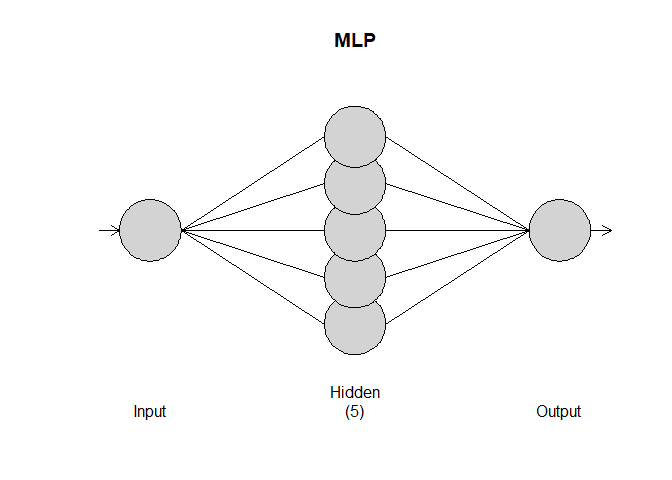

```r
plot(fit.fx4)
```

Step 2: Forecast the next 8 periods for the basic model using parameters derived from model fit summary

#### Results of Regressor Forecast for Consumer Confidence (fx4)

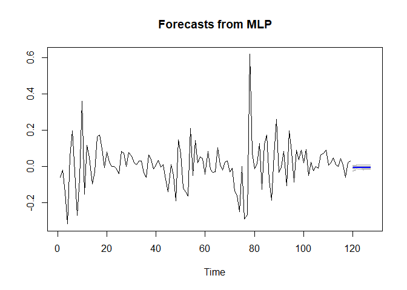

```r
fore.fx4 = forecast(fit.fx4, h=8)
plot(fore.fx4)
```

```r
fore.fx4
```

```
##     Point Forecast
## 120   -0.006397855
## 121   -0.006172288
## 122   -0.006648504
## 123   -0.006567821
## 124   -0.007416049
## 125   -0.007415893
## 126   -0.007366738
## 127   -0.007366447
```

```r
#Combine forecasted values with existing data
fx4 = EI$ConsumerConfidenceIndex[1:111]
fx4[112:119] = fore.fx4$mean[1:8]
```

**Part 2:** Construct multivariate MLP model using new regressor data estimates. Using multilayer perceptron to forecast 2 year (8 qtr) estimates for the quarterly change in US Consumption.

Step 1: Run multivariate MLP model. Allow program to select parameter estimates. Run 100 reps.

##### Multivariate Neural Network (NN4) Model fit Summary

```r
# combine forecasted regressor data into a new data frame
fx_regressor <- data.frame(fx1, fx2, fx3, fx4)

fit.nn3f = mlp(X_train, reps=100, xreg= fx_regressor)
fit.nn3f
```

```
## MLP fit with 5 hidden nodes and 100 repetitions.
## Univariate lags: (1,2,3)
## 4 regressors included.
## - Regressor 1 lags: (1,4)
## - Regressor 2 lags: (1)
## - Regressor 3 lags: (1)
## - Regressor 4 lags: (3)
## Forecast combined using the median operator.
## MSE: 0.0189.
```

#### Visual Diagram of Neural Network

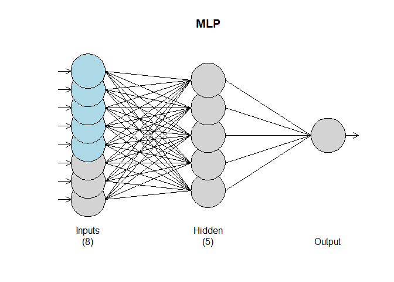

```r
plot(fit.nn3f)
```

Step 2: Forecast the next 8 periods for the multivariate model (NN4) using parameters derived from model fit summary

#### NN4 Model Forecast Results & Visual Plot

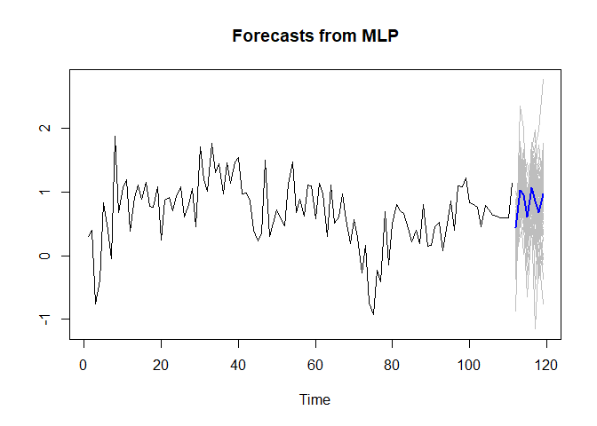

```r
fore.nn3f = forecast(fit.nn3f, h=8, xreg= fx_regressor)
plot(fore.nn3f)
```

```r
fore.nn3f
```

```
##     Point Forecast
## 112      0.4328670
## 113      1.0226249
## 114      0.9481543
## 115      0.6006219
## 116      1.0593647
## 117      0.8503196
## 118      0.6699473
## 119      0.9726301
```

Step 3: Compare forecasted datapoints to actual data points to visualize difference

##### NN4 Model Forecast Vs. Actual US Consumption Results

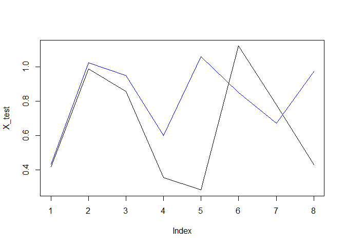

Step 4: Calculate ASE for future comparison purposes:

#### ASE for Multivariate Neural Network Model 4:

```r
nn3f.ASE = mean((X_test - fore.nn3f$mean)^2)
nn3f.ASE
```

```
## [1] 0.1315191
```

### **Ensemble Models**

We will look at 2 different Ensemble Models; 1 univariate and 1 multivariate.

The objective of each ensemble model is to help reduce the generalization error of the prediction. The rules for constructing each ensemble is as follows:  
1. Models are diverse: Models that ultilize different selection techniques will be chosen in order to reduce redundancy and maximize the benefits gained from diversifications. 2. Selected models produce independant results: Single model predictions must not depend on other or similiar models selected to be in the ensemble. Predicted results must be derived from using the model on a stand-alone basis. 3. Selection Criteria hierarchy: Analysis type, modeling technique, ASE performance.

#### **Univariate Ensemble Model**

The univariate ensemble model seeks to optimize forecasting results by combining the top performing ARIMA model with the top performing univariate neural network model. Benefits include:  
1. Offsetting risk of uncertainity through increased diversification.

#### Univariate Ensemble Model Plot

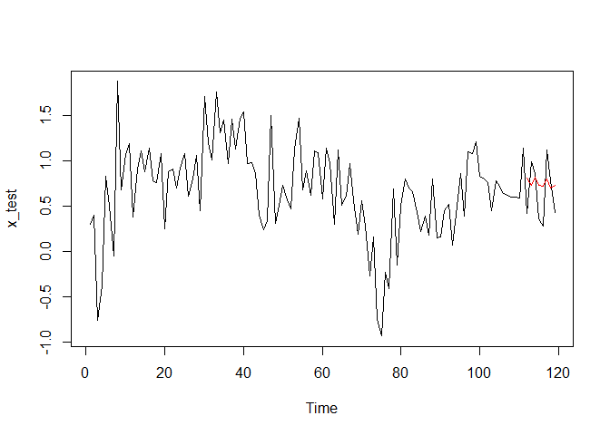

```r
fore.e1 = (fore.nn1$mean + fAR2$f)/2
plot(x_test, type="l")
lines(seq(112,119,1), fore.e1, col="red")
```

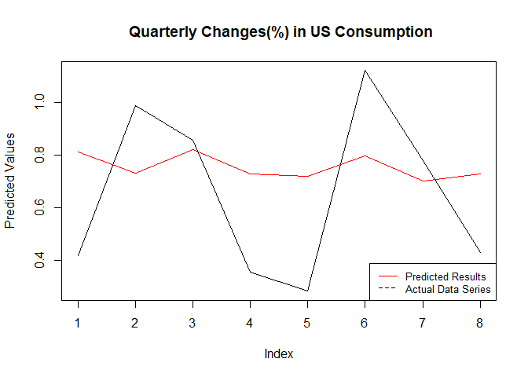

```r
name1 <- "Predicted Results"
value1 <- fore.e1

color1 <-"red"
color2 <-"Blue"

plot(X_test, type="l",
     ylab= "Predicted Values",
main= " Quarterly Changes(%) in US Consumption")
lines(seq(1,8), value1, col=color1)
# Add a legend
legend("bottomright", legend=c(name1, "Actual Data Series"),
       col=c(color1, "black"), lty=1:2, cex=0.8)
```

#### Univariate Ensemble Model ASE Score

```r
e1.ASE = mean((X_test- fore.e1)^2)
e1.ASE
```

```
## [1] 0.09380846
```

#### Multivariate Ensemble Model Plot

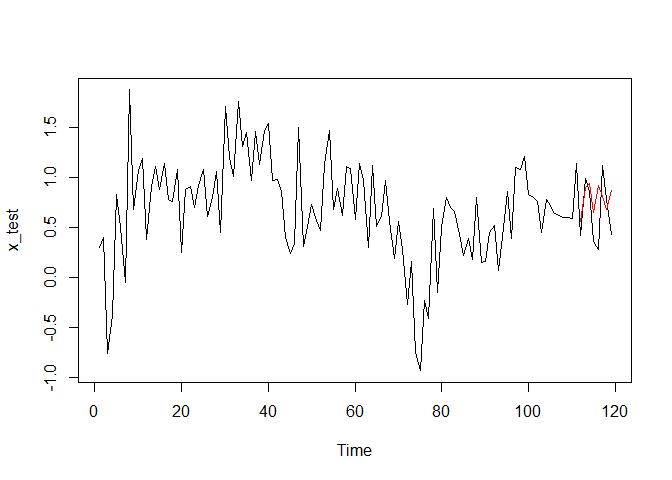

```r
fore.e2 = (fore.nn3f $mean + preds$fcst$x1[,1])/2
plot(x_test, type="l")
lines(seq(112,119,1), fore.e2, col="red")
```

#### Ensemble Model 2: Predicted Vs. Actual Data Values

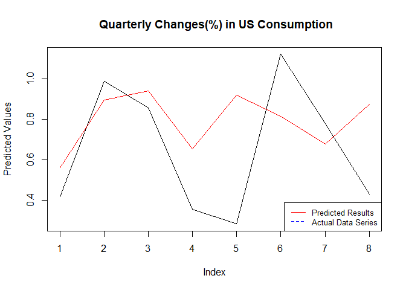

```r
name1 <- "Predicted Results"
value1 <- fore.e2

color1 <-"red"
color2 <-"Blue"

plot(X_test, type="l",
     ylab= "Predicted Values",
main= " Quarterly Changes(%) in US Consumption")
lines(seq(1,8), value1, col=color1)
# Add a legend
legend("bottomright", legend=c(name1, "Actual Data Series"),
       col=c(color1, color2, "black"), lty=1:2, cex=0.8)
```

#### Multivariate Ensemble Model ASE Score

```r
ensemble2.ASE = mean((X_test- fore.e2)^2)
ensemble2.ASE
```

```
## [1] 0.1036266
```

## **Comparing Models to determine best fit**

Model Comparison Structure is as follows:

```
**Univariate Model Comparisons**
```

1. ARIMA Model Comparison
2. Univariate Neural Network Model Comparison
3. ARIMA Vs. Neural Network

**Multivariate Model Comparisons**  
1. VAR Model Comparison 2. Multivariate Neural Network Comparison 3. VAR vs. Neural Network

** Ensemble Model Comparisons** 1. Univariate Vs. Multivariate

#### **ARIMA Model 1 (2,1,0) vs. ARIMA Model 2(3,1,0)**

ARIMA MOdel 1: ARIMA Model(2,1,0) ARIMA MOdel 2: ARIMA Model(3,1,0)

#### ARIMA Model Comparison: Predicted Vs. Actual Time Series:

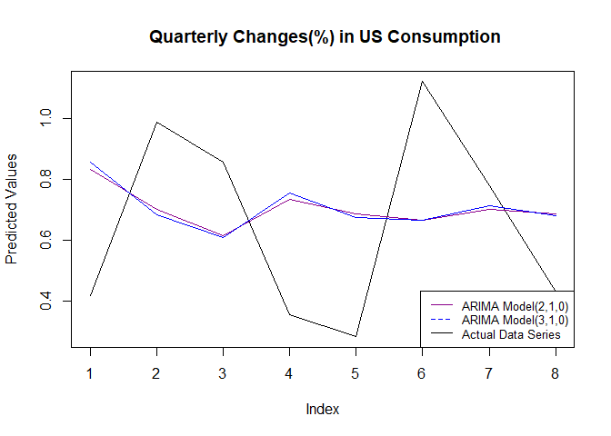

```r
name1 <- "ARIMA Model(2,1,0)"
value1 <- fAR2$f
ase1 <- ARIMA_210.ASE
ase1_title <- "ARIMA Model(2,1,0) ASE Score:"

name2 <- "ARIMA Model(3,1,0)"
value2 <-fAR3$f
ase2 <- ARIMA_310.ASE
ase2_title <- "ARIMA Model(3,1,0) ASE Score:"

color1 <-"dark Magenta"
color2 <-"Blue"

plot(X_test, type="l",
     ylab= "Predicted Values",
main= " Quarterly Changes(%) in US Consumption")
lines(seq(1,8), value1, col=color1)
lines(seq(1,8), value2, col=color2)
# Add a legend
legend("bottomright", legend=c(name1, name2, "Actual Data Series"),
       col=c(color1, color2, "black"), lty=1:2, cex=0.8)
```

```r
print(paste(ase1_title, round(ase1, digits=4)))
```

```
## [1] "ARIMA Model(2,1,0) ASE Score: 0.1119"
```

```r
print(paste(ase2_title, round(ase2, digits=4)))
```

```
## [1] "ARIMA Model(3,1,0) ASE Score: 0.1162"
```

#### **Neural Network Model 1 vs. Neural Network Model 2**

Neural Network Model 1: Basic MLP Model (Base Model) Neural Network Model 2: MLP Model (with Difference Order= 1)

#### Neural Network Comparison: Predicted Vs. Actual Time Series:

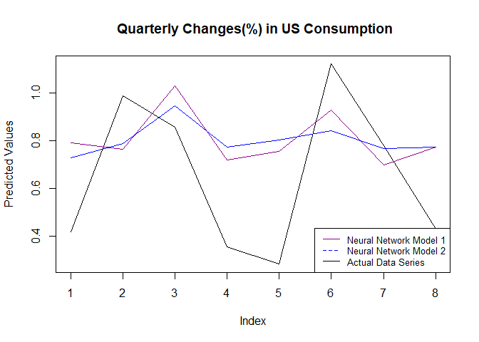

```r
name1 <- "Neural Network Model 1"
value1 <- fore.nn1$mean
ase1 <- nn1.ASE
ase1_title <- "Neural Network Model 1 ASE Score:"

name2 <- "Neural Network Model 2"
value2 <-fore.nn2$mean
ase2 <- nn2.ASE
ase2_title <- "Neural Network Model 2 ASE Score:"

color1 <-"dark Magenta"
color2 <-"Blue"

plot(X_test, type="l",
     ylab= "Predicted Values",
main= " Quarterly Changes(%) in US Consumption")
lines(seq(1,8), value1, col=color1)
lines(seq(1,8), value2, col=color2)
# Add a legend
legend("bottomright", legend=c(name1, name2, "Actual Data Series"),
       col=c(color1, color2, "black"), lty=1:2, cex=0.8)
```

```r
print(paste(ase1_title, round(ase1, digits=4)))
```

```
## [1] "Neural Network Model 1 ASE Score: 0.0918"
```

```r
print(paste(ase2_title, round(ase2, digits=4)))
```

```
## [1] "Neural Network Model 2 ASE Score: 0.0979"
```

#### Top Performing ARIMA Model Vs. Top Performing Neural Network Model:

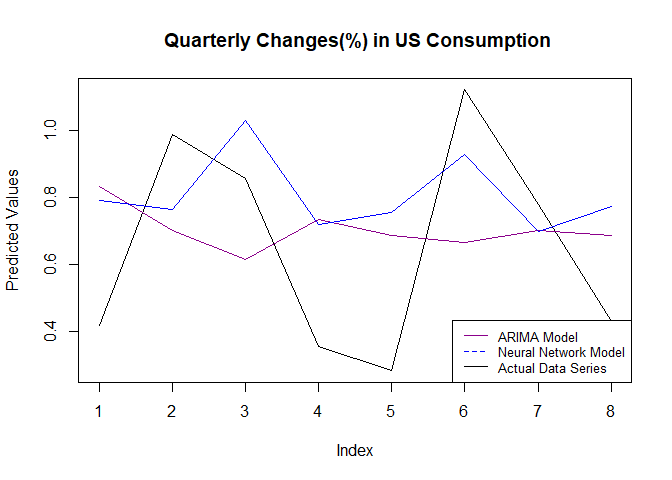

```r
name1 <- "ARIMA Model"
value1 <- fAR2$f
ase1 <-ARIMA_210.ASE

name2 <- "Neural Network Model"
value2 <-fore.nn1$mean
ase2 <- nn1.ASE

color1 <-"Dark Magenta"
color2 <-"Blue"

plot(X_test, type="l",
     ylab= "Predicted Values",
main= " Quarterly Changes(%) in US Consumption")
lines(seq(1,8), value1, col=color1)
lines(seq(1,8), value2, col=color2)
# Add a legend
legend("bottomright", legend=c(name1, name2, "Actual Data Series"),
       col=c(color1, color2, "black"), lty=1:2, cex=0.8)
```

```r
print(paste("ARIMA Model (2,1,0) ASE Score:", round(ase1, digits=4)))
```

```
## [1] "ARIMA Model (2,1,0) ASE Score: 0.1119"
```

```r
print(paste("Neural Network Model 1 ASE Score:", round(ase2, digits=4)))
```

```
## [1] "Neural Network Model 1 ASE Score: 0.0918"
```

#### **VAR Model 1 vs. VAR Model 2**

VAR Model 1: VAR Model fitted to p=5 (Basic Model) VAR Model 2: VAR Model fitted to p=5 (with Difference Order= 1)

#### VAR Model Comparison: Predicted Vs. Actual Time Series:

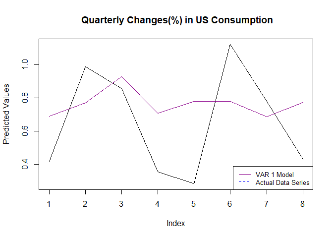

```r
name1 <- "VAR 1 Model"
value1 <- preds$fcst$x1[,1]
ase1 <- VAR1.ASE
ase1_title <- "VAR 1 Model ASE Score:"

name2 <- "VAR 2 Model"
value2 <-preds.dX$fcst$dx1[,1]
ase2 <- VAR2.ASE
ase2_title <- "VAR 2 Model ASE Score:"

color1 <-"dark Magenta"
color2 <-"Blue"

plot(X_test, type="l",
     ylab= "Predicted Values",
main= " Quarterly Changes(%) in US Consumption")
lines(seq(1,8), value1, col=color1)
#lines(seq(1,8), value2, col=color2)
# Add a legend
legend("bottomright", legend=c( name1,  "Actual Data Series"),
       col=c(color1, color2,  "black"), lty=1:2, cex=0.8)
```

```r
print(paste(ase1_title, round(ase1, digits=4)))
```

```
## [1] "VAR 1 Model ASE Score: 0.0925"
```

```r
#print(paste(ase2_title, round(ase2, digits=4)))
```

#### **Neural Network Model 3 vs. Neural Network Model 4**

Neural Network Model 3: multivariate MLP model with known regressors Neural Network Model 4: multivariate MLP model with Regressor forecasts

#### Neural Network Comparison: Predicted Vs. Actual Time Series:

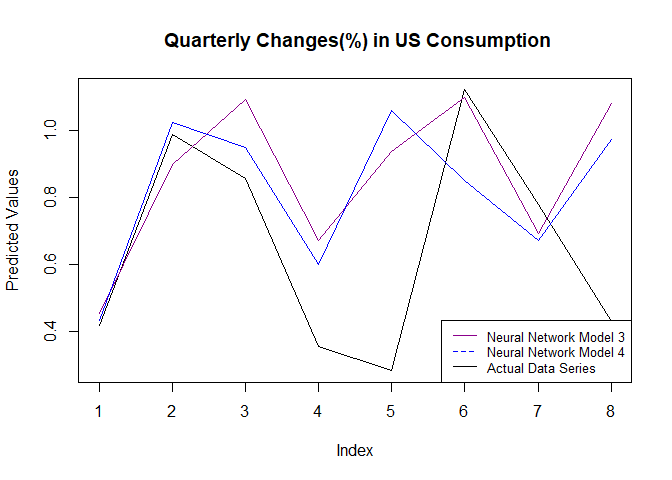

```r
name1 <- "Neural Network Model 3"
value1 <- fore.nn3$mean
ase1 <- nn3.ASE
ase1_title <- "Neural Network Model 3 ASE Score:"

name2 <- "Neural Network Model 4"
value2 <-fore.nn3f$mean
ase2 <- nn3f.ASE
ase2_title <- "Neural Network Model 4 ASE Score:"

color1 <-"dark Magenta"
color2 <-"Blue"

plot(X_test, type="l",
     ylab= "Predicted Values",
main= " Quarterly Changes(%) in US Consumption")
lines(seq(1,8), value1, col=color1)
lines(seq(1,8), value2, col=color2)
# Add a legend
legend("bottomright", legend=c(name1, name2, "Actual Data Series"),
       col=c(color1, color2, "black"), lty=1:2, cex=0.8)
```

```r
print(paste(ase1_title, round(ase1, digits=4)))
```

```
## [1] "Neural Network Model 3 ASE Score: 0.1281"
```

```r
print(paste(ase2_title, round(ase2, digits=4)))
```

```
## [1] "Neural Network Model 4 ASE Score: 0.1315"
```

#### Top Performing VAR Model Vs. Top Performing Neural Network Model:

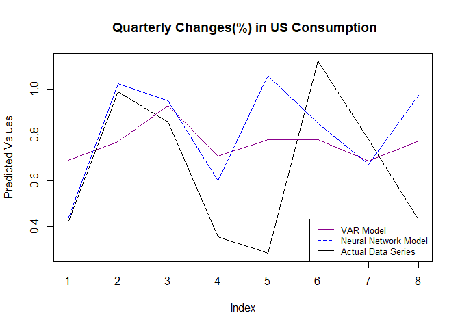

```r
name1 <- "VAR Model"
value1 <- preds$fcst$x1[,1]
ase1 <- VAR1.ASE
ase1_title <- "VAR Model ASE Score:"


name2 <- "Neural Network Model"
value2 <-fore.nn3f$mean
ase2 <- nn3f.ASE
ase2_title <- "Neural Network Model ASE Score:"

color1 <-"Dark Magenta"
color2 <-"Blue"

plot(X_test, type="l",
     ylab= "Predicted Values",
main= " Quarterly Changes(%) in US Consumption")
lines(seq(1,8), value1, col=color1)
lines(seq(1,8), value2, col=color2)
# Add a legend
legend("bottomright", legend=c(name1, name2, "Actual Data Series"),
       col=c(color1, color2, "black"), lty=1:2, cex=0.8)
```

```r
print(paste(ase1_title, round(ase1, digits=4)))
```

```
## [1] "VAR Model ASE Score: 0.0925"
```

```r
print(paste(ase2_title, round(ase2, digits=4)))
```

```
## [1] "Neural Network Model ASE Score: 0.1315"
```

#### **Top Performing: Univariate vs. Multivariate Model**

Top Performing Univariate Model: Neural Network Model 1  
Top Performing Multivariate Model: VAR 1 Model

#### Top Performing VAR Model Vs. Top Performing Neural Network Model:

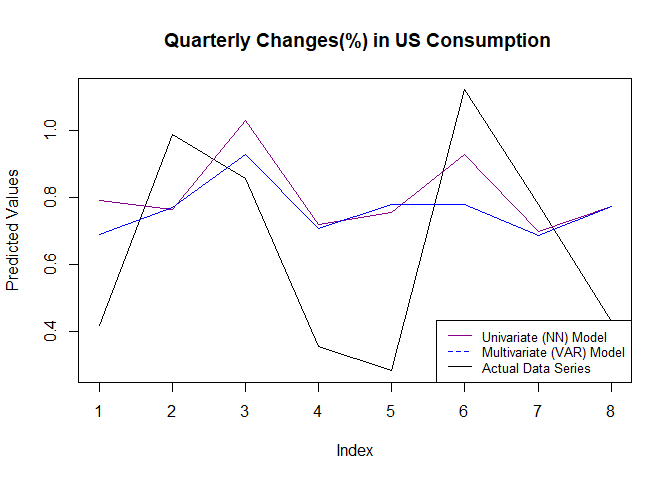

```r
name1 <- "Univariate (NN) Model"
value1 <- fore.nn1$mean
ase1 <- nn1.ASE
ase1_title <- "Univariate Model ASE Score:"

name2 <- "Multivariate (VAR) Model"
value2 <- preds$fcst$x1[,1]
ase2 <- VAR1.ASE
ase2_title <- "Multivariate Model ASE Score:"

color1 <-"Dark Magenta"
color2 <-"Blue"

plot(X_test, type="l",
     ylab= "Predicted Values",
main= " Quarterly Changes(%) in US Consumption")
lines(seq(1,8), value1, col=color1)
lines(seq(1,8), value2, col=color2)
# Add a legend
legend("bottomright", legend=c(name1, name2, "Actual Data Series"),
       col=c(color1, color2, "black"), lty=1:2, cex=0.8)
```

```r
print(paste(ase1_title, round(ase1, digits=4)))
```

```
## [1] "Univariate Model ASE Score: 0.0918"
```

```r
print(paste(ase2_title, round(ase2, digits=4)))
```

```
## [1] "Multivariate Model ASE Score: 0.0925"
```

#### **Ensemble 1 Vs. Ensemble 2 Model**

Univariate Ensemble Model: ARIMA Model (2,1,0) & NN1 Model Multivariate Ensemble Model: VAR1 model & NN4 model

#### Ensemble Model Comparison: Predicted Vs. Actual Time Series:

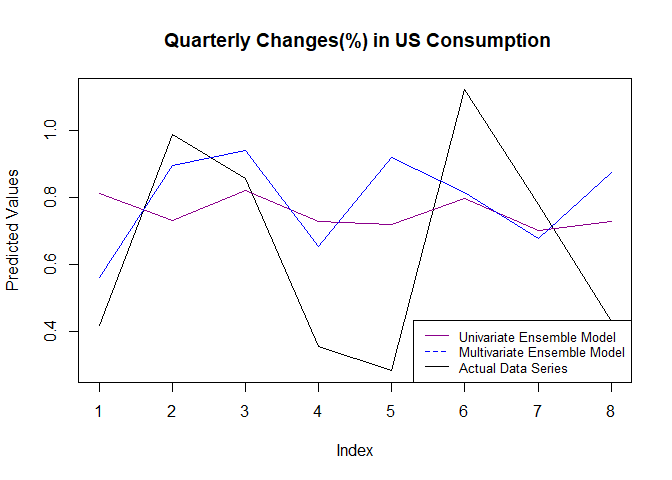

```r
name1 <- "Univariate Ensemble Model"
value1 <- fore.e1
ase1 <- e1.ASE
ase1_title <- "Univariate Ensemble Model ASE Score:"

name2 <- "Multivariate Ensemble Model"
value2 <- fore.e2
ase2 <- ensemble2.ASE
ase2_title <- "Multivariate Ensemble Model ASE Score:"

color1 <-"Dark Magenta"
color2 <-"Blue"

plot(X_test, type="l",
     ylab= "Predicted Values",
main= " Quarterly Changes(%) in US Consumption")
lines(seq(1,8), value1, col=color1)
lines(seq(1,8), value2, col=color2)
# Add a legend
legend("bottomright", legend=c(name1, name2, "Actual Data Series"),
       col=c(color1, color2, "black"), lty=1:2, cex=0.8)
```

```r
print(paste(ase1_title, round(ase1, digits=4)))
```

```
## [1] "Univariate Ensemble Model ASE Score: 0.0938"
```

```r
print(paste(ase2_title, round(ase2, digits=4)))
```

```
## [1] "Multivariate Ensemble Model ASE Score: 0.1036"
```

```r
cat("ASE Score for all Models reviewed in Study:\n\n",
"Univariate-ARIMA Models:\n",
"ARIMA Model (2,1,0) ASE Score:", round(ARIMA_210.ASE, digits=4),"\n",
"ARIMA Model (3,1,0) ASE Score:", round(ARIMA_310.ASE, digits=4),"\n\n",
"Univariate-NN Models:\n",
"Neural Network Model 1 ASE Score:", round(nn1.ASE, digits=4),"\n",
"Neural Network Model 2 ASE Score:", round(nn2.ASE, digits=4),"\n\n",
"Multivariate-VAR Models:\n",
"VAR Model 1 ASE Score:", round(VAR1.ASE, digits=4),"\n",
"VAR Model 2 ASE Score:", round(VAR2.ASE, digits=4),"\n\n",
"Multivariate-NN Models:\n",
"Neural Network Model 3 ASE Score:", round(nn3.ASE, digits=4),"\n",
"Neural Network Model 4 ASE Score:", round(nn3f.ASE, digits=4),"\n\n",
"Ensemble Models:\n",
"Univariate Ensemble Model ASE Score:", round(e1.ASE, digits=4),"\n",
"Multivariate Ensemble Model ASE Score:", round(ensemble2.ASE, digits=4),"\n\n",
"Top Performing Model:\n",
"Univariate (NN1) Model ASE Score:", round(nn1.ASE, digits=4),"\n",
"Multivariate (VAR1) Model ASE Score:", round(VAR1.ASE, digits=4))
```

```
## ASE Score for all Models reviewed in Study:
##
##  Univariate-ARIMA Models:
##  ARIMA Model (2,1,0) ASE Score: 0.1119
##  ARIMA Model (3,1,0) ASE Score: 0.1162
##
##  Univariate-NN Models:
##  Neural Network Model 1 ASE Score: 0.0918
##  Neural Network Model 2 ASE Score: 0.0979
##
##  Multivariate-VAR Models:
##  VAR Model 1 ASE Score: 0.0925
##  VAR Model 2 ASE Score: 0.5307
##
##  Multivariate-NN Models:
##  Neural Network Model 3 ASE Score: 0.1281
##  Neural Network Model 4 ASE Score: 0.1315
##
##  Ensemble Models:
##  Univariate Ensemble Model ASE Score: 0.0938
##  Multivariate Ensemble Model ASE Score: 0.1036
##
##  Top Performing Model:
##  Univariate (NN1) Model ASE Score: 0.0918
##  Multivariate (VAR1) Model ASE Score: 0.0925
```

## **Model Forecast**

Selected Model: Univariate Neural Network Model 1

##### Basic Neural Network (NNM final) Model fit Summary

```r
fX_train = as.ts(EI$U.S.Consumption[1:119])
fit.nnm = mlp(fX_train, reps = 100)
fit.nnm
```

```
## MLP fit with 5 hidden nodes and 100 repetitions.
## Univariate lags: (1,2,3)
## Forecast combined using the median operator.
## MSE: 0.1035.
```

#### Visual Diagram of Neural Network

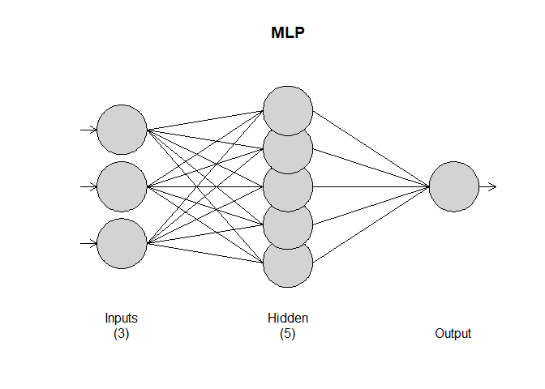

```r
plot(fit.nnm)
```

Step 2: Forecast the next 8 periods for the basic model (NN1) using parameters derived from model fit summary

#### NN1 Model Forecast Results & Visual Plot

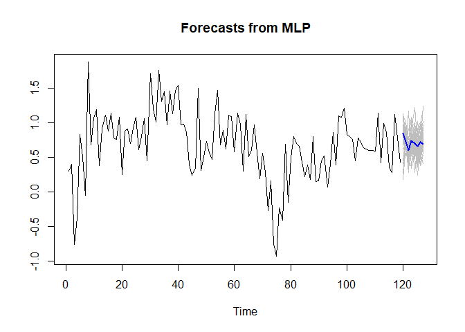

```r
fore.nnm = forecast(fit.nnm, h=8)
plot(fore.nnm)
```

#### NN1 Model Forecast Results & with confidence Interval

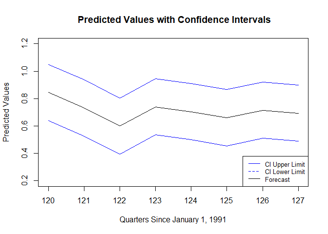

```r
UL = fore.nnm$mean + (1.98 * fit.nnm$MSE)
LL = fore.nnm$mean - (1.98 * fit.nnm$MSE)
fnnm.df = data.frame(fore.nnm$mean, UL, LL)

plot(fnnm.df$fore.nnm.mean, type="l",
     ylab= "Predicted Values", xlab = "Quarters Since January 1, 1991",
main= " Predicted Values with Confidence Intervals",  ylim=c(.2,1.2))
lines(seq(120,127), fnnm.df$UL, col="blue")
lines(seq(120,127), fnnm.df$LL, col="blue")
# Add a legend
legend("bottomright", legend=c("CI Upper Limit", "CI Lower Limit", "Forecast"),
       col=c("blue", "blue", "black"), lty=1:2, cex=0.8)
```

## **APPENDIX: Additional Modeling of Secondary Variables**

### **Simple AR Model Forecasts for each Regressor Data Variable**

Step 1: Generate independant forecasts (using the standard AR model identification method) for each underlying variable that is used in today’s analysis. Steps include:  
1. Run AIC to determine P&Q 2. Fit model using Burg Estimates  
3. Forecast the next 8 quarters using selected model

#### Basic AR Model: US Consumption (x1) Independant Variable Forecast

```r
p1=aic.wge(x1,p=0:8,q=0:0)
p1 # aic picks p=4
```

```
## $type
## [1] "aic"
##
## $value
## [1] -1.783758
##
## $p
## [1] 4
##
## $q
## [1] 0
##
## $phi
## [1]  0.2666940  0.2336611  0.3792276 -0.1658038
##
## $theta
## [1] 0
##
## $vara
## [1] 0.1535318
```

```r
x1.est=est.ar.wge(x1,p=p1$p)
```

```
##
## Coefficients of Original polynomial:
## 0.2667 0.2337 0.3792 -0.1658
##
## Factor                 Roots                Abs Recip    System Freq
## 1-0.8169B              1.2242               0.8169       0.0000
## 1+0.9174B+0.5527B^2   -0.8300+-1.0585i      0.7434       0.3558
## 1-0.3672B              2.7230               0.3672       0.0000
##
##
##
## Coefficients of Original polynomial:
## 0.2667 0.2337 0.3792 -0.1658
##
## Factor                 Roots                Abs Recip    System Freq
## 1-0.8169B              1.2242               0.8169       0.0000
## 1+0.9174B+0.5527B^2   -0.8300+-1.0585i      0.7434       0.3558
## 1-0.3672B              2.7230               0.3672       0.0000
##
##
```

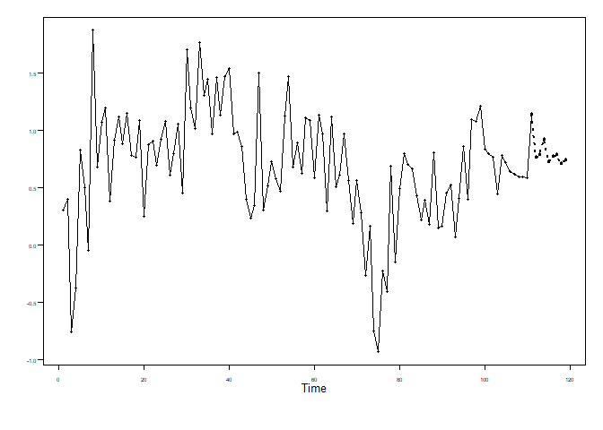

```
## $f
## [1] 0.7628105 0.7886581 0.9184718 0.7246388 0.7755324 0.7887575 0.7091460
## [8] 0.7424428
##
## $ll
## [1]  0.01640882  0.01616814  0.11318060 -0.17022503 -0.12594106 -0.12926230
## [7] -0.22674203 -0.19574859
##
## $ul
## [1] 1.509212 1.561148 1.723763 1.619503 1.677006 1.706777 1.645034 1.680634
##
## $resid
##   [1]  0.00000000  0.00000000  0.00000000  0.00000000  0.81269470
##   [6]  0.52542443 -0.55642961  1.19760752 -0.05547550  0.36011002
##  [11] -0.16608517 -0.32691673  0.03934616  0.31179906  0.22696495
```

[output cut: 31 more lines]

```r
fore.arma.wge(x1,phi=x1.est$phi,n.ahead=8,lastn=FALSE,limits=FALSE)
```

#### Basic AR Model: US Disposable Income (x2) Variable Forecast

```r
p2=aic.wge(x2,p=0:8,q=0:0)
p2 # aic picks p=2
```

```
## $type
## [1] "aic"
##
## $value
## [1] -0.3232312
##
## $p
## [1] 2
##
## $q
## [1] 0
##
## $phi
## [1] -0.1806925  0.1738748
##
## $theta
## [1] 0
##
## $vara
## [1] 0.6857205
```

```r
x2.est=est.ar.wge(x2,p=p2$p)
```

```
##
## Coefficients of Original polynomial:
## -0.1807 0.1739
##
## Factor                 Roots                Abs Recip    System Freq
## 1+0.5170B             -1.9342               0.5170       0.5000
## 1-0.3363B              2.9734               0.3363       0.0000
##
##
##
## Coefficients of Original polynomial:
## -0.1807 0.1739
##
## Factor                 Roots                Abs Recip    System Freq
## 1+0.5170B             -1.9342               0.5170       0.5000
## 1-0.3363B              2.9734               0.3363       0.0000
##
##
```

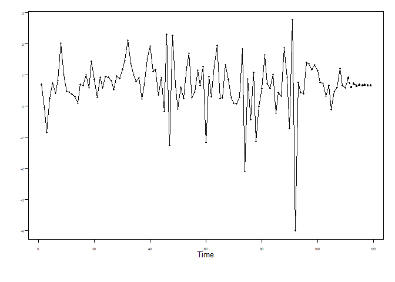

```
## $f
## [1] 0.6081475 0.7203003 0.6473177 0.6800056 0.6614093 0.6704531 0.6655856
## [8] 0.6680376
##
## $ll
## [1] -1.0248039 -0.9390947 -1.0460003 -1.0170282 -1.0374586 -1.0287505
## [7] -1.0337338 -1.0313080
##
## $ul
## [1] 2.241099 2.379695 2.340636 2.377039 2.360277 2.369657 2.364905 2.367383
##
## $resid
##   [1]  0.0000000000  0.0000000000 -1.6519100383 -0.5697582360  0.2533147632
##   [6] -0.1747256286  0.1061719935  1.4200017637  0.5389955458 -0.3785618765
##  [11] -0.3048733843 -0.2959548573 -0.3739359813 -0.5937598692 -0.0148204476
```

[output cut: 31 more lines]

```r
fore.arma.wge(x2,phi=x2.est$phi,n.ahead=8,lastn=FALSE,limits=FALSE)
```

#### Basic AR Model: Personal Income per Capita (x3) Variable Forecast

```r
p3=aic.wge(x3,p=0:8,q=0:0)
p3 # aic picks p=2
```

```
## $type
## [1] "aic"
##
## $value
## [1] -0.2542559
##
## $p
## [1] 2
##
## $q
## [1] 0
##
## $phi
## [1] 0.1032843 0.2579579
##
## $theta
## [1] 0
##
## $vara
## [1] 0.7346876
```

```r
x3.est=est.ar.wge(x3,p=p3$p)
```

```
##
## Coefficients of Original polynomial:
## 0.1033 0.2580
##
## Factor                 Roots                Abs Recip    System Freq
## 1-0.5622B              1.7789               0.5622       0.0000
## 1+0.4589B             -2.1793               0.4589       0.5000
##
##
##
## Coefficients of Original polynomial:
## 0.1033 0.2580
##
## Factor                 Roots                Abs Recip    System Freq
## 1-0.5622B              1.7789               0.5622       0.0000
## 1+0.4589B             -2.1793               0.4589       0.5000
##
##
```

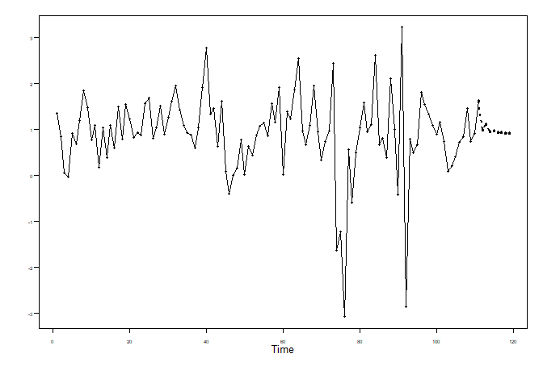

```
## $f
## [1] 0.9872793 1.1043004 0.9520184 0.9664766 0.9286876 0.9285141 0.9187482
## [8] 0.9176948
##
## $ll
## [1] -0.7061943 -0.5981820 -0.8101931 -0.7981403 -0.8404836 -0.8410410
## [7] -0.8511839 -0.8522871
##
## $ul
## [1] 2.680753 2.806783 2.714230 2.731093 2.697859 2.698069 2.688680 2.687677
##
## $resid
##   [1]  0.00000000  0.00000000 -0.96979064 -0.83838101  0.32136836
##   [6]  0.01603399  0.31338811  0.96795971  0.40085496 -0.43976065
##  [11]  0.04305189 -0.72305209  0.16125295 -0.33911707  0.19489608
```

[output cut: 31 more lines]

```r
fore.arma.wge(x3,phi=x3.est$phi,n.ahead=8,lastn=FALSE,limits=FALSE)
```

#### Basic AR Model: Consumer Debt (x4) Variable Forecast

```r
#x4 Consumer Debtforecast
p4=aic.wge(x4,p=0:8,q=0:0)
p4 # aic picks p=2
```

```
## $type
## [1] "aic"
##
## $value
## [1] -0.08915802
##
## $p
## [1] 2
##
## $q
## [1] 0
##
## $phi
## [1] 0.4133098 0.2950579
##
## $theta
## [1] 0
##
## $vara
## [1] 0.8665703
```

```r
x4.est=est.ar.wge(x4,p=p4$p)
```

```
##
## Coefficients of Original polynomial:
## 0.4133 0.2951
##
## Factor                 Roots                Abs Recip    System Freq
## 1-0.7878B              1.2693               0.7878       0.0000
## 1+0.3745B             -2.6701               0.3745       0.5000
##
##
##
## Coefficients of Original polynomial:
## 0.4133 0.2951
##
## Factor                 Roots                Abs Recip    System Freq
## 1-0.7878B              1.2693               0.7878       0.0000
## 1+0.3745B             -2.6701               0.3745       0.5000
##
##
```

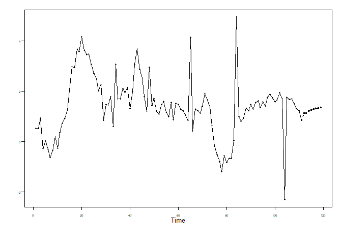

```
## $f
## [1] 1.134623 1.135594 1.218205 1.252635 1.291241 1.317355 1.339540 1.356414
##
## $ll
## [1] -0.7032778 -0.8531011 -0.9469893 -0.9883873 -1.0030567 -1.0071791
## [7] -1.0042087 -0.9989917
##
## $ul
## [1] 2.972525 3.124289 3.383399 3.493658 3.585538 3.641890 3.683288 3.711820
##
## $resid
##   [1]  0.000000000  0.000000000  0.157988845 -1.227719504 -0.564007450
##   [6] -0.632017199 -0.930812716 -0.423291320  0.097249924 -0.652893459
##  [11]  0.012708403  0.254202710  0.106791244  0.229139253  0.832237014
##  [16]  1.355369192  0.719935678  1.169364183  0.773790293  1.184502789
```

[output cut: 30 more lines]

```r
fore.arma.wge(x4,phi=x4.est$phi,n.ahead=8,lastn=FALSE,limits=FALSE)
```

#### Basic AR Model: Consumer Confidence (x5) Variable Forecast

```r
p5=aic.wge(x5,p=0:8,q=0:0)
p5 # aic picks p=2
```

```
## $type
## [1] "aic"
##
## $value
## [1] -4.154696
##
## $p
## [1] 2
##
## $q
## [1] 0
##
## $phi
## [1] -0.01249389 -0.21837091
##
## $theta
## [1] 0
##
## $vara
## [1] 0.01486493
```

```r
x5.est=est.ar.wge(x5,p=p5$p)
```

```
##
## Coefficients of Original polynomial:
## -0.0125 -0.2184
##
## Factor                 Roots                Abs Recip    System Freq
## 1+0.0125B+0.2184B^2   -0.0286+-2.1398i      0.4673       0.2521
##
##
##
## Coefficients of Original polynomial:
## -0.0125 -0.2184
##
## Factor                 Roots                Abs Recip    System Freq
## 1+0.0125B+0.2184B^2   -0.0286+-2.1398i      0.4673       0.2521
##
##
```

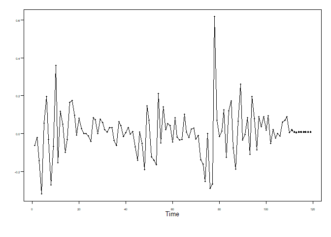

```
## $f
## [1] 0.008593535 0.005645768 0.007935526 0.008550625 0.008042923 0.007914947
## [7] 0.008027413 0.008053954
##
## $ll
## [1] -0.2321750 -0.2351415 -0.2385171 -0.2379055 -0.2386794 -0.2388077
## [7] -0.2387079 -0.2386814
##
## $ul
## [1] 0.2493621 0.2464331 0.2543882 0.2550068 0.2547652 0.2546376 0.2547627
## [8] 0.2547893
##
## $resid
##   [1]  0.000000000  0.000000000 -0.165579029 -0.334256824  0.009592512
##   [6]  0.116649018 -0.025920759 -0.238457486 -0.088258527  0.291158090
```

[output cut: 32 more lines]

```r
fore.arma.wge(x5,phi=x5.est$phi,n.ahead=8,lastn=FALSE,limits=FALSE)
```

### ** AR Model Forecasts using Differenced Data for each Regressor Time Series**

Step 1: We begin my taking the differences of the data to make them stationary.

Step 2: Generate independant forecasts (using the standard AR model identification method) for each underlying variable that is used in today’s analysis. Steps include:  
1. Run AIC to determine P&Q 2. Fit model using Burg Estimates  
3. Forecast the next 8 quarters using selected model

#### (Differenced Data) AR Model 2: US Consumption (x1) Independant Variable Forecast

```r
dp1=aic.wge(dx1,p=0:8,q=0:0)
dp1 # aic picks p=2
```

```
## $type
## [1] "aic"
##
## $value
## [1] -1.732658
##
## $p
## [1] 2
##
## $q
## [1] 0
##
## $phi
## [1] -0.7125446 -0.4382164
##
## $theta
## [1] 0
##
## $vara
## [1] 0.1674278
```

```r
dx1.est=est.ar.wge(dx1,p=dp1$p)
```

```
##
## Coefficients of Original polynomial:
## -0.7125 -0.4382
##
## Factor                 Roots                Abs Recip    System Freq
## 1+0.7125B+0.4382B^2   -0.8130+-1.2732i      0.6620       0.3404
##
##
##
## Coefficients of Original polynomial:
## -0.7125 -0.4382
##
## Factor                 Roots                Abs Recip    System Freq
## 1+0.7125B+0.4382B^2   -0.8130+-1.2732i      0.6620       0.3404
##
##
```

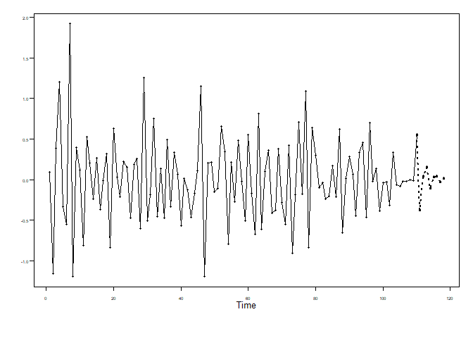

```
## $f
## [1] -0.37407637  0.04064108  0.15129132 -0.10928791  0.02789766  0.04433692
## [7] -0.02749376  0.01648485
##
## $ll
## [1] -1.1637261 -0.9289638 -0.8198657 -1.1023567 -0.9799351 -0.9639897
## [7] -1.0372036 -0.9945362
##
## $ul
## [1] 0.4155734 1.0102460 1.1224483 0.8837809 1.0357304 1.0526636 0.9822161
## [8] 1.0275060
##
## $resid
##   [1]  0.000000000  0.000000000 -0.416196497  0.956297187  0.681357191
##   [6] -0.273286315  1.370593278 -0.080507212  0.368857992 -0.139226128
```

[output cut: 31 more lines]

```r
fore.arma.wge(dx1,phi=dx1.est$phi,n.ahead=8,lastn=FALSE,limits=FALSE)
```